# Data605_final_wzhou

Wei Zhou

12/14/2019

Youtube Link

## Problem 1

**Calculate as a minimum the below probabilities a through c. Assume the small letter “x” is estimated as the median of the X variable, and the small letter “y” is estimated as the 1st quartile of the Y variable. Interpret the meaning of all probabilities.**

Generate random variable X , Y

```r
set.seed(12345)
N <- 10
n <- 10000
mu <- sigma <- (N + 1)/2
df <- data.frame(X = runif(n, min=1, max=N),
                 Y = rnorm(n, mean=mu, sd=sigma))
summary(df$X)
```

```
##    Min. 1st Qu.  Median    Mean 3rd Qu.    Max.
##   1.000   3.283   5.541   5.506   7.742  10.000
```

```r
summary(df$Y)
```

```
##    Min. 1st Qu.  Median    Mean 3rd Qu.    Max.
## -14.664   1.846   5.482   5.500   9.154  26.766
```

Probability:

```r
## Given that:
x <- median(df$X)
y <- as.numeric(quantile(df$Y)["25%"])
x
```

```
## [1] 5.540952
```

```r
y
```

```
## [1] 1.846076
```

1. $P(X>x|X>y)$ Interpretation:Probability that X is greater than its median given that X is greater than the first quartile of Y

$P(X>x|X>y) = \frac{P(X>x,X>y)}{P(X>y)}$

```r
P_Xx_and_Xy <- df %>%
  filter(X > x,
         X > y) %>%
  nrow() / n
P_Xy <- df %>%
  filter(X > y) %>%
  nrow() / n
ans_1a <- P_Xx_and_Xy / P_Xy
ans_1a
```

```
## [1] 0.5512679
```

2. $P(X>x,Y>y)$ Interpretation: Probability that X is grater than its median and Y is greater than the first quartile of Y.

```r
ans_1b <- df %>%
  filter(X > x,
         Y > y) %>%
  nrow() / n
ans_1b
```

```
## [1] 0.3808
```

3. $P(X<x|X>y)$ Interpretation: Probability that X is smaller than its median given that X is greate than the first quartile of Y.

```r
P_Xsx_and_Xgy <- df %>%
  filter(X < x,
         X > y) %>%
  nrow() / n
P_Xgy <- df %>%
  filter(X > y) %>%
  nrow() / n
ans_1c <- P_Xsx_and_Xgy / P_Xgy
ans_1c
```

```
## [1] 0.4487321
```

**Investigate whether P(X>x and Y>y)=P(X>x)P(Y>y) by building a table and evaluating the marginal and joint probabilities.**

```r
# Create Joint Probabilities
temp <- df %>%
  mutate(A = ifelse(X > x, " X > x", " X <= x"),
         B = ifelse(Y > y, " Y > y", " Y <= y")) %>%
  group_by(A, B) %>%
  summarise(count = n()) %>%
  mutate(probability = count / n)
# Create Marginal Probabilities
temp <- temp %>%
  ungroup() %>%
  group_by(A) %>%
  summarise(count = sum(count),
            probability = sum(probability)) %>%
  mutate(B = "Total") %>%
  bind_rows(temp)
temp <- temp %>%
  ungroup() %>%
  group_by(B) %>%
  summarise(count = sum(count),
            probability = sum(probability)) %>%
  mutate(A = "Total") %>%
  bind_rows(temp)

# Create Table
temp %>%
  select(-count) %>%
  spread(A, probability) %>%
  rename(" " = B) %>%
  kable() %>%
  kable_styling()
```

|  | X <= x | X > x | Total |
| --- | --- | --- | --- |
| Y <= y | 0.1308 | 0.1192 | 0.25 |
| Y > y | 0.3692 | 0.3808 | 0.75 |
| Total | 0.5000 | 0.5000 | 1.00 |

**Check to see if independence holds by using Fisher’s Exact Test and the Chi Square Test. What is the difference between the two? Which is most appropriate?**

```r
count_data <- temp %>%
  filter(A != "Total",
         B != "Total") %>%
  select(-probability) %>%
  spread(A, count) %>%
  as.data.frame()
row.names(count_data) <- count_data$B
count_data <- count_data %>%
  select(-B) %>%
  as.matrix()
fisher.test(count_data)
```

```
    Fisher's Exact Test for Count Data

data:  count_data
p-value = 0.007904
alternative hypothesis: true odds ratio is not equal to 1
95 percent confidence interval:
 1.032680 1.240419
sample estimates:
odds ratio
  1.131777
```

```r
chisq.test(count_data)
```

```
    Pearson's Chi-squared test with Yates' continuity correction

data:  count_data
X-squared = 7.0533, df = 1, p-value = 0.007912
```

*Fisher’s Exact Test is for is used when sample size less than 5, while the Chi Square Test is used when the cell sizes are large. In this case, Chi Square would be appropriate.*

# Problem 2

**5 points. Descriptive and Inferential Statistics. Provide univariate descriptive statistics and appropriate plots for the training data set. Provide a scatterplot matrix for at least two of the independent variables and the dependent variable. Derive a correlation matrix for any THREE quantitative variables in the dataset. Test the hypotheses that the correlations between each pairwise set of variables is 0 and provide a 80% confidence interval. Discuss the meaning of your analysis. Would you be worried about familywise error? Why or why not?**

**Load Data**

```r
# Load training data from GitHub
train <- read.csv('https://raw.githubusercontent.com/weizhou2273/DATA605/master/hw/data/train.csv')
test <- read.csv('https://raw.githubusercontent.com/weizhou2273/DATA605/master/hw/data/test.csv')
```

### Descriptive and Inferential Statistics

**Provide univariate descriptive statistics and appropriate plots for the training data set.**

```r
summary(train)
```

```
##        Id           MSSubClass       MSZoning     LotFrontage
##  Min.   :   1.0   Min.   : 20.0   C (all):  10   Min.   : 21.00
##  1st Qu.: 365.8   1st Qu.: 20.0   FV     :  65   1st Qu.: 59.00
##  Median : 730.5   Median : 50.0   RH     :  16   Median : 69.00
##  Mean   : 730.5   Mean   : 56.9   RL     :1151   Mean   : 70.05
##  3rd Qu.:1095.2   3rd Qu.: 70.0   RM     : 218   3rd Qu.: 80.00
##  Max.   :1460.0   Max.   :190.0                  Max.   :313.00
##                                                  NA's   :259
##     LotArea        Street      Alley      LotShape  LandContour
##  Min.   :  1300   Grvl:   6   Grvl:  50   IR1:484   Bnk:  63
##  1st Qu.:  7554   Pave:1454   Pave:  41   IR2: 41   HLS:  50
##  Median :  9478               NA's:1369   IR3: 10   Low:  36
##  Mean   : 10517                           Reg:925   Lvl:1311
##  3rd Qu.: 11602
##  Max.   :215245
##
##   Utilities      LotConfig    LandSlope   Neighborhood   Condition1
##  AllPub:1459   Corner : 263   Gtl:1382   NAmes  :225   Norm   :1260
##  NoSeWa:   1   CulDSac:  94   Mod:  65   CollgCr:150   Feedr  :  81
##                FR2    :  47   Sev:  13   OldTown:113   Artery :  48
##                FR3    :   4              Edwards:100   RRAn   :  26
##                Inside :1052              Somerst: 86   PosN   :  19
##                                          Gilbert: 79   RRAe   :  11
##                                          (Other):707   (Other):  15
##    Condition2     BldgType      HouseStyle   OverallQual
##  Norm   :1445   1Fam  :1220   1Story :726   Min.   : 1.000
##  Feedr  :   6   2fmCon:  31   2Story :445   1st Qu.: 5.000
##  Artery :   2   Duplex:  52   1.5Fin :154   Median : 6.000
##  PosN   :   2   Twnhs :  43   SLvl   : 65   Mean   : 6.099
##  RRNn   :   2   TwnhsE: 114   SFoyer : 37   3rd Qu.: 7.000
##  PosA   :   1                 1.5Unf : 14   Max.   :10.000
##  (Other):   2                 (Other): 19
##   OverallCond      YearBuilt     YearRemodAdd    RoofStyle
##  Min.   :1.000   Min.   :1872   Min.   :1950   Flat   :  13
##  1st Qu.:5.000   1st Qu.:1954   1st Qu.:1967   Gable  :1141
##  Median :5.000   Median :1973   Median :1994   Gambrel:  11
##  Mean   :5.575   Mean   :1971   Mean   :1985   Hip    : 286
##  3rd Qu.:6.000   3rd Qu.:2000   3rd Qu.:2004   Mansard:   7
##  Max.   :9.000   Max.   :2010   Max.   :2010   Shed   :   2
##
```

[output cut: 89 more lines]

```
##  GdPrv:  59   Gar2:   2   Min.   :    0.00   Min.   : 1.000
##  GdWo :  54   Othr:   2   1st Qu.:    0.00   1st Qu.: 5.000
##  MnPrv: 157   Shed:  49   Median :    0.00   Median : 6.000
##  MnWw :  11   TenC:   1   Mean   :   43.49   Mean   : 6.322
##  NA's :1179   NA's:1406   3rd Qu.:    0.00   3rd Qu.: 8.000
##                           Max.   :15500.00   Max.   :12.000
##
##      YrSold        SaleType    SaleCondition    SalePrice
##  Min.   :2006   WD     :1267   Abnorml: 101   Min.   : 34900
##  1st Qu.:2007   New    : 122   AdjLand:   4   1st Qu.:129975
##  Median :2008   COD    :  43   Alloca :  12   Median :163000
##  Mean   :2008   ConLD  :   9   Family :  20   Mean   :180921
##  3rd Qu.:2009   ConLI  :   5   Normal :1198   3rd Qu.:214000
##  Max.   :2010   ConLw  :   5   Partial: 125   Max.   :755000
##                 (Other):   9
```

**Provide a scatterplot matrix for at least two of the independent variables and the dependent variable.**

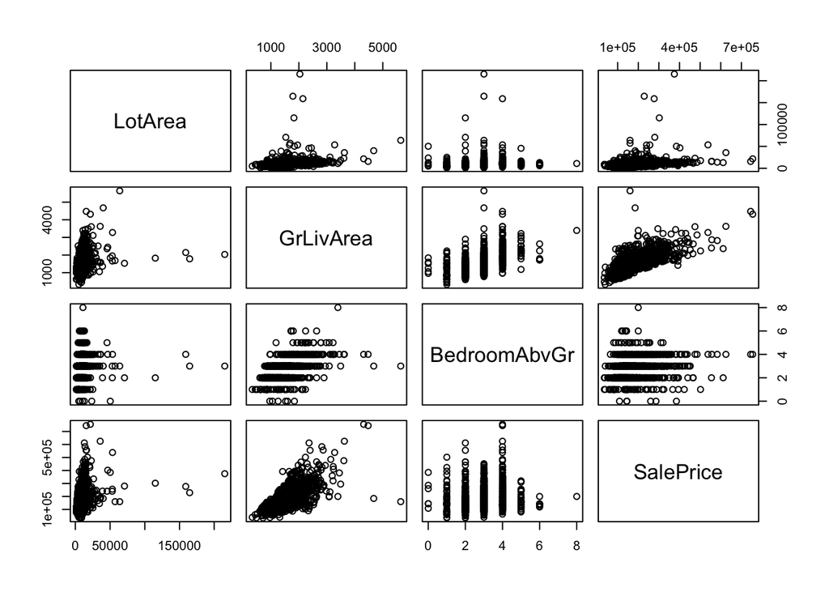

```r
train %>%
  select(LotArea, GrLivArea, BedroomAbvGr, SalePrice) %>%
  pairs()
```

**Derive a correlation matrix for any three quantitative variables in the dataset.**

```r
correlation_matrix <- train %>%
  select(LotArea, GrLivArea, BedroomAbvGr) %>%
  cor() %>%
  as.matrix()
correlation_matrix %>%
  kable() %>%
  kable_styling()
```

|  | LotArea | GrLivArea | BedroomAbvGr |
| --- | --- | --- | --- |
| LotArea | 1.0000000 | 0.2631162 | 0.1196899 |
| GrLivArea | 0.2631162 | 1.0000000 | 0.5212695 |
| BedroomAbvGr | 0.1196899 | 0.5212695 | 1.0000000 |

**Test the hypothesis that the correlations between each pairwise set of variables is 0 and provide an 80% confidence interval.**

```r
zero_vars <- 0
test <- 0
variables <- train %>%
  select(-SalePrice) %>%
  names()
for(variable in variables){
  d <- train[,names(train) == variable]
  if(is.numeric(d)){
    test <- test + 1
    results <- cor.test(train$SalePrice, d, conf.level = 0.8)
    if(0 > results$conf.int[1] & results$conf.int[2] > 0){
      hypothesis_test_results <- "Yes"
      zero_vars <- zero_vars + 1
    } else {
      hypothesis_test_results <- "No"
    }
    print(paste(variable,': test result', hypothesis_test_results))
  }
}
```

[1] “Id : test result Yes” [1] “MSSubClass : test result No” [1] “LotFrontage : test result No” [1] “LotArea : test result No” [1] “OverallQual : test result No” [1] “OverallCond : test result No” [1] “YearBuilt : test result No” [1] “YearRemodAdd : test result No” [1] “MasVnrArea : test result No” [1] “BsmtFinSF1 : test result No” [1] “BsmtFinSF2 : test result Yes” [1] “BsmtUnfSF : test result No” [1] “TotalBsmtSF : test result No” [1] “X1stFlrSF : test result No” [1] “X2ndFlrSF : test result No” [1] “LowQualFinSF : test result Yes” [1] “GrLivArea : test result No” [1] “BsmtFullBath : test result No” [1] “BsmtHalfBath : test result Yes” [1] “FullBath : test result No” [1] “HalfBath : test result No” [1] “BedroomAbvGr : test result No” [1] “KitchenAbvGr : test result No” [1] “TotRmsAbvGrd : test result No” [1] “Fireplaces : test result No” [1] “GarageYrBlt : test result No” [1] “GarageCars : test result No” [1] “GarageArea : test result No” [1] “WoodDeckSF : test result No” [1] “OpenPorchSF : test result No” [1] “EnclosedPorch : test result No” [1] “X3SsnPorch : test result No” [1] “ScreenPorch : test result No” [1] “PoolArea : test result No” [1] “MiscVal : test result Yes” [1] “MoSold : test result No” [1] “YrSold : test result Yes”

**Discuss the meaning of your analysis. Would you be worried about familywise error? Why or why not?**

*There are 6 variables that have no correlation with the sale price.*

*They are Id, BsmtFinSF2, LowQualFinSF, BsmtHalfBath,MiscVal , YrSold*

*I would be worried be woried about family-wise error.*

*The family-wise error rate would be: ${FWER} = 1 - (1 - .2)^6 = 1 - 0.262144 = 0.737856$. This means there is a really high probability of committing a Type I error.*

### Linear Algebra and Correlation

**Invert your correlation matrix from above. (This is known as the precision matrix and contains variance inflation factors on the diagonal.)**

```r
precision_matrix <- inv(correlation_matrix)
precision_matrix %>%
  kable() %>%
  kable_styling()
```

| 1.0748631 | -0.2962500 | 0.0257758 |
| --- | --- | --- |
| -0.2962500 | 1.4547532 | -0.7228604 |
| 0.0257758 | -0.7228604 | 1.3737200 |

**Multiply the correlation matrix by the precision matrix, and then multiply the precision matrix by the correlation matrix.**

*This will generate the identity matrix.*

```r
correlation_matrix %*% precision_matrix %>%
  round() %>%
  kable() %>%
  kable_styling()
```

| LotArea | 1 | 0 | 0 |
| --- | --- | --- | --- |
| GrLivArea | 0 | 1 | 0 |
| BedroomAbvGr | 0 | 0 | 1 |

*This will too.*

```r
precision_matrix %*% correlation_matrix %>%
  round() %>%
  kable() %>%
  kable_styling()
```

| LotArea | GrLivArea | BedroomAbvGr |
| --- | --- | --- |
| 1 | 0 | 0 |
| 0 | 1 | 0 |
| 0 | 0 | 1 |

**Conduct LU decomposition on the matrix.**

```r
lu_decomposition <- Matrix::expand(lu(correlation_matrix))
```

*The LU decomposition should yield the correlation matrix after multiplying the two components. In other words this:*

```r
A <- lu_decomposition$L %*% lu_decomposition$U %>%
  as.matrix()
colnames(A) <- colnames(correlation_matrix)
rownames(A) <- rownames(correlation_matrix)
A %>%
  kable() %>%
  kable_styling()
```

|  | LotArea | GrLivArea | BedroomAbvGr |
| --- | --- | --- | --- |
| LotArea | 1.0000000 | 0.2631162 | 0.1196899 |
| GrLivArea | 0.2631162 | 1.0000000 | 0.5212695 |
| BedroomAbvGr | 0.1196899 | 0.5212695 | 1.0000000 |

*Should match this:*

```r
correlation_matrix %>%
  kable() %>%
  kable_styling()
```

|  | LotArea | GrLivArea | BedroomAbvGr |
| --- | --- | --- | --- |
| LotArea | 1.0000000 | 0.2631162 | 0.1196899 |
| GrLivArea | 0.2631162 | 1.0000000 | 0.5212695 |
| BedroomAbvGr | 0.1196899 | 0.5212695 | 1.0000000 |

*Which it does.*

### Calculus-Based Probability & Statistics

**Many times, it makes sense to fit a closed form distribution to data. Select a variable in the Kaggle.com training dataset that is skewed to the right, shift it so that the minimum value is absolutely above zero if necessary. Then load the MASS package and run fitdistr to fit an exponential probability density function. (See https://stat.ethz.ch/R-manual/R-devel/library/MASS/html/fitdistr.html). Find the optimal value of $\lambda$ for this distribution, and then take 1000 samples from this exponential distribution using this value (e.g., rexp(1000, $\lambda$)).**

*I will be using the Square Footage of the Unfinished Basement for this part of the exam. I know it is right skewed because the mean (567.240411) is larger than the median (477.5) as shown in the figure below:*

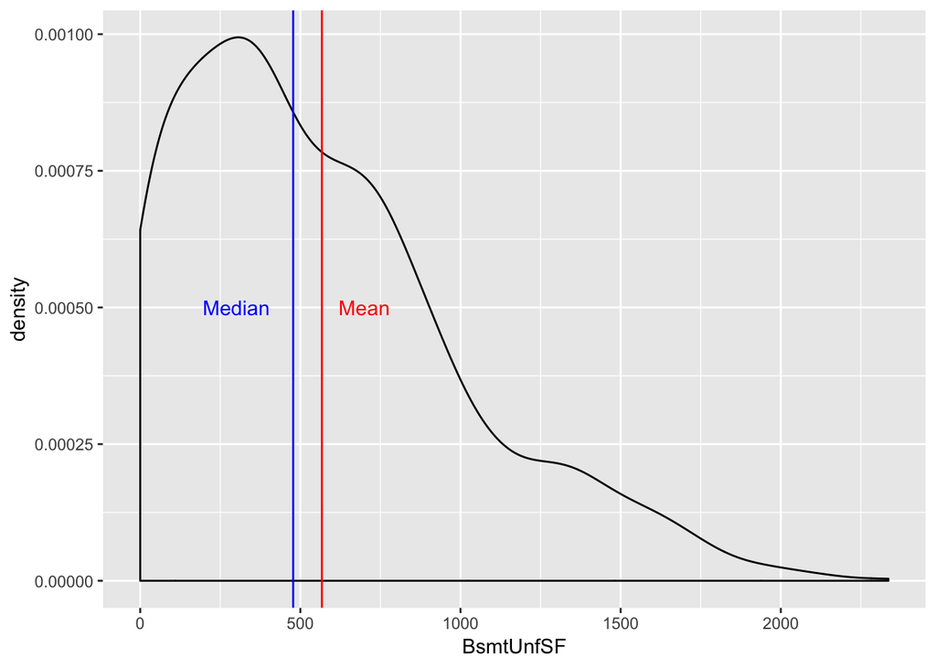

*The minimum (0) is not smaller than zero so we don’t need to shift the data. Remember that the maximum value is 2336. I have already loaded the MASS package.*

```r
lambda <- fitdistr(train$BsmtUnfSF, densfun = "exponential")$estimate
```

*The optimal value for $\lambda$ is 0.0017629.*

```r
samples <- rexp(1000, rate = lambda)
```

**Plot a histogram and compare it with a histogram of your original variable.**

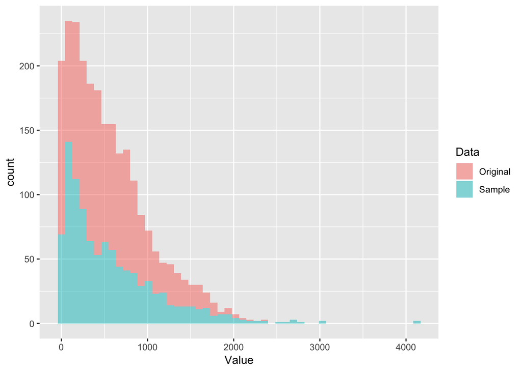

*The original data is not quite exponential, but it’s not a bad approximation. The exponential distribution data has a longer tail than the basement square footage data.*

**Using the exponential pdf, find the 5th and 95th percentiles using the cumulative distribution function (CDF).**

*The PDF would be $f(x;\lambda) = \lambda e^{-\lambda x}$ where $x \geq 0$ and otherwise zero.*

*The CDF would be $F(x;\lambda) = 1 - e^{-\lambda x}$. lambda is 0.0017629. To find the 5th percentile we need to solve for x in:*

$$0.05 = 1 - e^{-0.0017629 x}$$

$$-0.95 = - e^{-0.0017629 x}$$

$$-ln(0.95) = 0.0017629 x$$

$$x = \frac{-ln(0.95)}{0.0017629} = 29.0956294$$
*For the 95th percentile we need to solve for x in:*

$$0.95 = 1 - e^{-0.0017629 x}$$

$$-0.05 = - e^{-0.0017629 x}$$

$$-ln(0.05) = 0.0017629 x$$

$$x = \frac{-ln(0.05)}{0.0017629} = 1699.300406$$

*So the 5th and 95th percentiles are approximately 29 and 1699, respectively.*

**Also generate a 95% confidence interval from the empirical data, assuming normality.**

```r
mu <- mean(train$BsmtUnfSF)
s <- sd(train$BsmtUnfSF)
n <- nrow(train)
error <- qnorm(0.975) * s / sqrt(n)
ci <- c(mu - error, mu + error)
names(ci) <- c("5%", "95%")
ci
```

```
      5%      95%
544.5750 589.9058
```

*The 95% confidence interval (assuming normality) is 545 to 590. Although what I think was meant was assume the data is normally distributed. Calculate the 5th and 95th percentile. That is found using $x = \mu + Z \sigma$. The Z is -1.645 for the 5th percentile, and 1.645 for the 95th. So the percentiles would be -160 and 1294.*

**Finally, provide the empirical 5th percentile and 95th percentile of the data. Discuss.**

```r
quantile(train$BsmtUnfSF, c(0.05, 0.95))
```

```
  5%  95%
   0 1468
```

*The actual 5th percentile is 0 and the 95th is 1468. So the findings are summarized in the following table:*

| Method | 5% | 95% |
| --- | --- | --- |
| Exponential CDF | 29 | 1699 |
| Normal 95% CI | 545 | 590 |
| Normal Percentiles | -160 | 1294 |
| Emperical Percentiles | 0 | 1468 |

*If we model the data as exponentially distributed the 5th percentile is 29. If we model it as normally distributed the 5th is at -160 which in the context of square footage does not make any sense. The actual 5th percentile is 0. The difference is explained to the assumed shape/distibution of the underlying data.*

*I have left out the 95% CI from the discussion because the confidence interval is a way of estimating the mean of the population. We would know if we took 100 estimates that the actual mean falls within the confidence intervals 95% of the time. Within this context it is meaningless.*

### Modeling

**Build some type of multiple regression model and submit your model to the competition board. Provide your complete model summary and results with analysis. Report your Kaggle.com user name and score.**

```r
fill_holes <- function(df){
  df %>%
    mutate(BedroomAbvGr = replace_na(BedroomAbvGr, 0),
           BsmtFullBath = replace_na(BsmtFullBath, 0),
           BsmtHalfBath = replace_na(BsmtHalfBath, 0),
           BsmtUnfSF = replace_na(BsmtUnfSF, 0),
          EnclosedPorch = replace_na(EnclosedPorch, 0),
          Fireplaces = replace_na(Fireplaces, 0),
          GarageArea = replace_na(GarageArea, 0),
          GarageCars = replace_na(GarageCars, 0),
          HalfBath = replace_na(HalfBath, 0),
          KitchenAbvGr = replace_na(KitchenAbvGr, 0),
          LotFrontage = replace_na(LotFrontage, 0),
          OpenPorchSF = replace_na(OpenPorchSF, 0),
          PoolArea = replace_na(PoolArea, 0),
          ScreenPorch = replace_na(ScreenPorch, 0),
          TotRmsAbvGrd = replace_na(TotRmsAbvGrd, 0),
          WoodDeckSF = replace_na(WoodDeckSF, 0))
}
train = fill_holes(train)
test <- read.csv('https://raw.githubusercontent.com/weizhou2273/DATA605/master/hw/data/test.csv')
test  = fill_holes(test)
```

```r
model <- lm(SalePrice ~ OverallQual + YearBuilt + YearRemodAdd + TotalBsmtSF + X1stFlrSF + GrLivArea + FullBath + TotRmsAbvGrd + GarageCars + GarageArea, data = train)

summary(model)
```

```
##
## Call:
## lm(formula = SalePrice ~ OverallQual + YearBuilt + YearRemodAdd +
##     TotalBsmtSF + X1stFlrSF + GrLivArea + FullBath + TotRmsAbvGrd +
##     GarageCars + GarageArea, data = train)
##
## Residuals:
##     Min      1Q  Median      3Q     Max
## -489958  -19316   -1948   16020  290558
##
## Coefficients:
##                Estimate Std. Error t value Pr(>|t|)
## (Intercept)  -1.186e+06  1.291e+05  -9.187  < 2e-16 ***
## OverallQual   1.960e+04  1.190e+03  16.472  < 2e-16 ***
## YearBuilt     2.682e+02  5.035e+01   5.328 1.15e-07 ***
## YearRemodAdd  2.965e+02  6.363e+01   4.659 3.47e-06 ***
## TotalBsmtSF   1.986e+01  4.295e+00   4.625 4.09e-06 ***
## X1stFlrSF     1.417e+01  4.930e+00   2.875 0.004097 **
## GrLivArea     5.130e+01  4.233e+00  12.119  < 2e-16 ***
## FullBath     -6.791e+03  2.682e+03  -2.532 0.011457 *
## TotRmsAbvGrd  3.310e+01  1.119e+03   0.030 0.976404
## GarageCars    1.042e+04  3.044e+03   3.422 0.000639 ***
## GarageArea    1.495e+01  1.031e+01   1.450 0.147384
## ---
## Signif. codes:  0 '***' 0.001 '**' 0.01 '*' 0.05 '.' 0.1 ' ' 1
##
## Residual standard error: 37920 on 1449 degrees of freedom
## Multiple R-squared:  0.7737, Adjusted R-squared:  0.7721
## F-statistic: 495.4 on 10 and 1449 DF,  p-value: < 2.2e-16
```

```r
mySalePrice <- predict(model,test)

##create dataframe
prediction <- data.frame( Id = test[,"Id"],  SalePrice = mySalePrice)
prediction[prediction<0] <- 0
prediction <- replace(prediction,is.na(prediction),0)

head(prediction)
```

```
##     Id SalePrice
## 1 1461  110135.9
## 2 1462  159060.0
## 3 1463  169683.7
## 4 1464  188059.7
## 5 1465  219782.0
## 6 1466  182152.0
```

```r
#write.csv(prediction, file="prediction.csv", row.names = FALSE)
```

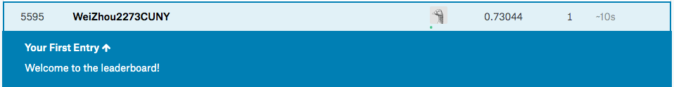

Username: WeiZhou2273CUNY, Score: 0.73044